# Time Series Forecasting of Energy Consumption in Romania

Oguzhan Gurbuz

2025-07-05

#INTRODUCTION

#Reliable energy consumption forecasting plays a vital role in ensuring the efficiency, sustainability, and stability of national energy systems. For Romania, a country undergoing significant energy transition toward renewable sources, understanding consumption dynamics is crucial for optimizing production and supporting policy planning.

#This project uses an open dataset collected from Kaggle, which contains hourly electricity consumption and production data for Romania from 2019 to 2024. The dataset records total energy consumption and generation, along with detailed production by source, including nuclear, hydroelectric, coal, oil and gas, wind, solar, and biomass.

#Through time series analysis, the project aims to provide an empirically grounded understanding of Romania’s energy demand trends and to develop an accurate forecasting model that can serve as a valuable tool for energy planners, policymakers, and researchers working on sustainable energy systems and the country’s green transition.

# ======================================================

# STEP 1: LOAD AND INSPECT THE ENERGY DATASET

# ======================================================

```r
# Load necessary packages
library(tidyverse)
library(lubridate)
library(forecast)
```

```r
library(tseries)
library(readr)
library(ggplot2)
```

#The dataset is available at: https://www.kaggle.com/datasets/stefancomanita/hourly-electricity-consumption-and-production/data

#It contains hourly records of electricity consumption and production in Romania (2019–2024).

```r
#Let's load the dataset
energy_cons <- read.csv("energy_consumption_and_production_of_romania.csv")

#Checking if we loaded the dataset correctly
head(energy_cons)
```

```
##           DateTime Consumption Production Nuclear Wind Hydroelectric
## 1 01/01/2019 00:00        6352       6527    1395   79          1383
## 2 01/01/2019 01:00        6116       5701    1393   96          1112
## 3 01/01/2019 02:00        5873       5676    1393  142          1030
## 4 01/01/2019 03:00        5682       5603    1397  191           972
## 5 01/01/2019 04:00        5557       5454    1393  159           960
## 6 01/01/2019 05:00        5525       5385    1395   91           958
##   Oil.and.Gas Coal Solar Biomass
## 1        1896 1744     0      30
## 2        1429 1641     0      30
## 3        1465 1616     0      30
## 4        1455 1558     0      30
## 5        1454 1458     0      30
## 6        1455 1456     0      30
```

```r
#Let's review our data
glimpse(energy_cons)
```

```
## Rows: 54,170
## Columns: 10
## $ DateTime      <chr> "01/01/2019 00:00", "01/01/2019 01:00", "01/01/2019 02:0…
## $ Consumption   <int> 6352, 6116, 5873, 5682, 5557, 5525, 5513, 5524, 5510, 56…
## $ Production    <int> 6527, 5701, 5676, 5603, 5454, 5385, 5349, 5547, 5471, 55…
## $ Nuclear       <int> 1395, 1393, 1393, 1397, 1393, 1395, 1392, 1392, 1391, 13…
## $ Wind          <int> 79, 96, 142, 191, 159, 91, 98, 93, 51, 15, -5, -17, -10,…
## $ Hydroelectric <int> 1383, 1112, 1030, 972, 960, 958, 938, 1187, 1325, 1398, …
## $ Oil.and.Gas   <int> 1896, 1429, 1465, 1455, 1454, 1455, 1451, 1446, 1357, 13…
## $ Coal          <int> 1744, 1641, 1616, 1558, 1458, 1456, 1440, 1394, 1303, 13…
## $ Solar         <int> 0, 0, 0, 0, 0, 0, 0, 0, 8, 61, 126, 182, 206, 202, 160, …
## $ Biomass       <int> 30, 30, 30, 30, 30, 30, 31, 34, 34, 34, 34, 34, 34, 34, …
```

```r
#Checking if there's any null value
sum(is.na(energy_cons$Consumption)) #No null value in the "Consumption" data.
```

```
## [1] 0
```

# ======================================================

# STEP 2: DATA CLEANING AND PREPARATION

# ======================================================

#We will standardize and organize the dataset for time series analysis.

```r
energy_cons <- energy_cons %>%
  mutate(DateTime = dmy_hm(DateTime)) %>%  # convert to date-time format (dd/mm/yyyy hh:mm)
  arrange(DateTime)                        # ensure data is in chronological order
```

#Visualization of Hourly Energy Consumption in Romania

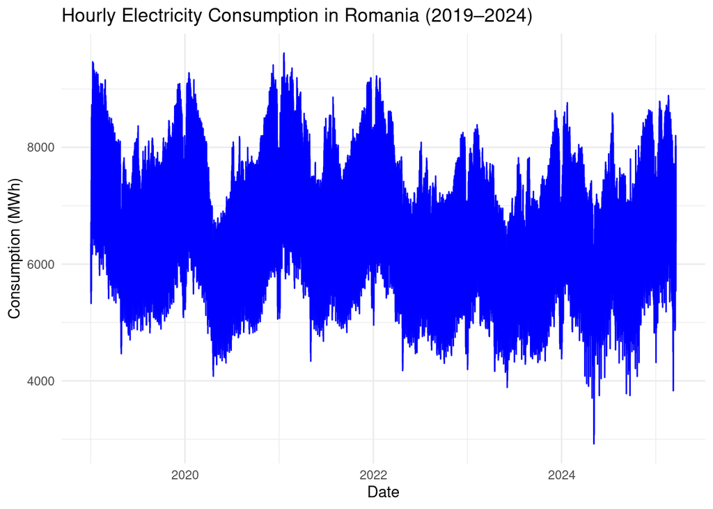

```r
ggplot(energy_cons, aes(x = DateTime, y = Consumption)) +
  geom_line(color = "blue") +
  labs(
    title = "Hourly Electricity Consumption in Romania (2019–2024)",
    x = "Date",
    y = "Consumption (MWh)"
  ) +
  theme_minimal()
```

#The chart and consumption follows a clear seasonal pattern. It peaks in winter and drops in summer, and displays strong daily and weekly fluctuations typical of energy use.

```r
#We can transform hourly observations into daily averages to smooth out high-frequency fluctuations and make seasonal and long-term patterns clearer.

daily_cons_data <- energy_cons %>%
  mutate(Date = as.Date(DateTime)) %>%           #remove hours/minutes
  group_by(Date) %>%
  summarise(
    Consumption   = mean(Consumption, na.rm = TRUE),
    Production    = mean(Production, na.rm = TRUE),
    Wind          = mean(Wind, na.rm = TRUE),
    Solar         = mean(Solar, na.rm = TRUE),
    Hydroelectric = mean(Hydroelectric, na.rm = TRUE)
  )

#Let's inspect the new daily data set and ensure there is one observation per day.
glimpse(daily_cons_data)
```

```
## Rows: 2,268
## Columns: 6
## $ Date          <date> 2019-01-01, 2019-01-02, 2019-01-03, 2019-01-04, 2019-01…
## $ Consumption   <dbl> 5957.667, 6322.042, 7254.083, 7635.083, 7379.750, 7005.8…
## $ Production    <dbl> 5924.417, 6795.708, 7202.250, 7988.500, 6836.208, 7061.7…
## $ Wind          <dbl> 343.5833, 1106.7500, 989.2917, 1854.5833, 629.5000, 1391…
## $ Solar         <dbl> 43.29167, 53.33333, 33.33333, 45.50000, 92.75000, 23.625…
## $ Hydroelectric <dbl> 1285.875, 1252.708, 1477.208, 1411.833, 1212.042, 1072.1…
```

```r
head(daily_cons_data)
```

```
## # A tibble: 6 × 6
##   Date       Consumption Production  Wind Solar Hydroelectric
##   <date>           <dbl>      <dbl> <dbl> <dbl>         <dbl>
## 1 2019-01-01       5958.      5924.  344.  43.3         1286.
## 2 2019-01-02       6322.      6796. 1107.  53.3         1253.
## 3 2019-01-03       7254.      7202.  989.  33.3         1477.
## 4 2019-01-04       7635.      7988. 1855.  45.5         1412.
## 5 2019-01-05       7380.      6836.  630.  92.8         1212.
## 6 2019-01-06       7006.      7062. 1391.  23.6         1072.
```

```r
nrow(daily_cons_data)
```

```
## [1] 2268
```

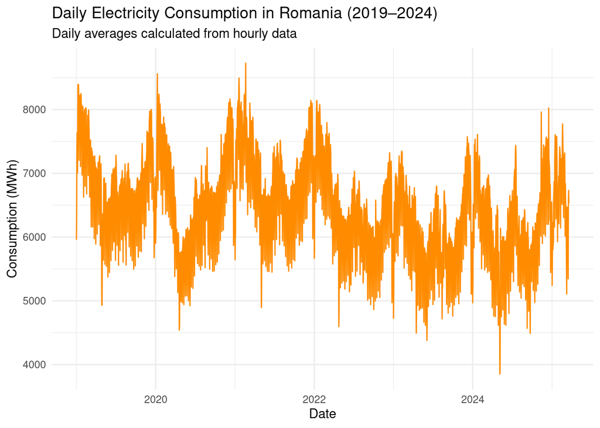

```r
#Visualize the daily electricity consumption

ggplot(daily_cons_data, aes(x = Date, y = Consumption)) +
  geom_line(color = "darkorange") +
  labs(
    title = "Daily Electricity Consumption in Romania (2019–2024)",
    subtitle = "Daily averages calculated from hourly data",
    x = "Date",
    y = "Consumption (MWh)"
  ) +
  theme_minimal()
```

#The daıly plot shows Romania’s daily electricity consumption (2019–2024) with clear seasonal cycles.

#Consumption peaks in winter and drops in summer, reflecting the seasonnal needs.

#The pattern looks consistent, which makes the data well-suited for forecasting.

# ======================================================

# STEP 4: CREATING THE TIME SERIES OBJECT & FITTING AN ARIMA MODEL

# ======================================================

```r
#Let's convert daily data into a time series object
#We specify the start year (2019) and the frequency (365 for daily data).
cons_ts <- ts(daily_cons_data$Consumption, start = c(2019, 1), frequency = 365)
```

#Visualization of the time series

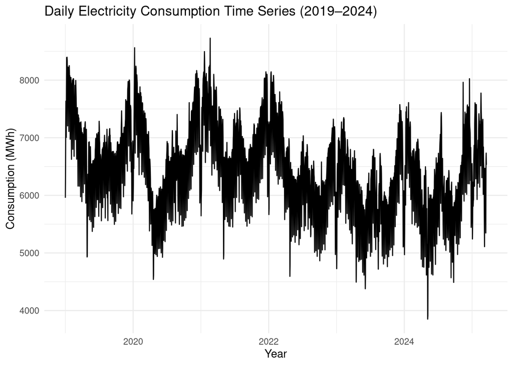

```r
#This helps confirm the data structure before modeling.
autoplot(cons_ts) +
  labs(
    title = "Daily Electricity Consumption Time Series (2019–2024)",
    x = "Year",
    y = "Consumption (MWh)"
  ) +
  theme_minimal()
```

#Fit an ARIMA model

```r
#The Autoregressive Integrated Moving Average (ARIMA) model is one of the most widely used statistical techniques for forecasting time series data.

#ARIMA automatically selects the best parameters to capture trend and autocorrelation in the data.

fit_arima <- auto.arima(cons_ts)

#Display model summary to see parameters (p, d, q) and performance metrics.
summary(fit_arima)
```

```
## Series: cons_ts
## ARIMA(5,1,2)
##
## Coefficients:
##          ar1      ar2      ar3      ar4      ar5      ma1     ma2
##       0.0918  -0.7605  -0.2851  -0.3411  -0.5810  -0.4479  0.5346
## s.e.  0.0271   0.0173   0.0245   0.0163   0.0212   0.0362  0.0170
##
## sigma^2 = 102798:  log likelihood = -16296.48
## AIC=32608.97   AICc=32609.03   BIC=32654.78
##
## Training set error measures:
##                      ME    RMSE     MAE        MPE     MAPE      MASE
## Training set -0.1976985 320.056 240.287 -0.2211403 3.792642 0.4228041
##                     ACF1
## Training set -0.05353628
```

#The ARIMA(5,1,2) model was automatically selected as the best fit for Romania’s daily electricity consumption series (2019–2024).

#This indicates that:

#AR(5): the model uses the previous five days of consumption to predict the next day, capturing medium-term dependencies.

#I(1): first-order differencing to remove trend; the data is differenced once to remove trend and make the series stationary.

#MA(2): two moving average terms; the model incorporates the forecast errors from the previous two days to correct short-term fluctuations.

#Model Performance

#RMSE (Root Mean Square Error): 320.056 MWh

#MAE (Mean Absolute Error): 240.29 MWh

#MAPE (Mean Absolute Percentage Error): 3.79%

#These values indicate that the model’s predictions deviate from actual daily consumption by only around 3.8% on average, which demonstrates strong predictive accuracy for time series forecasting.

#The low mean error (ME ≈ 0) suggests the model is unbiased, with no systematic over / or / underestimation.

# ======================================================

# STEP 5: 60-DAY FORECAST USING ARIMA MODEL

# ======================================================

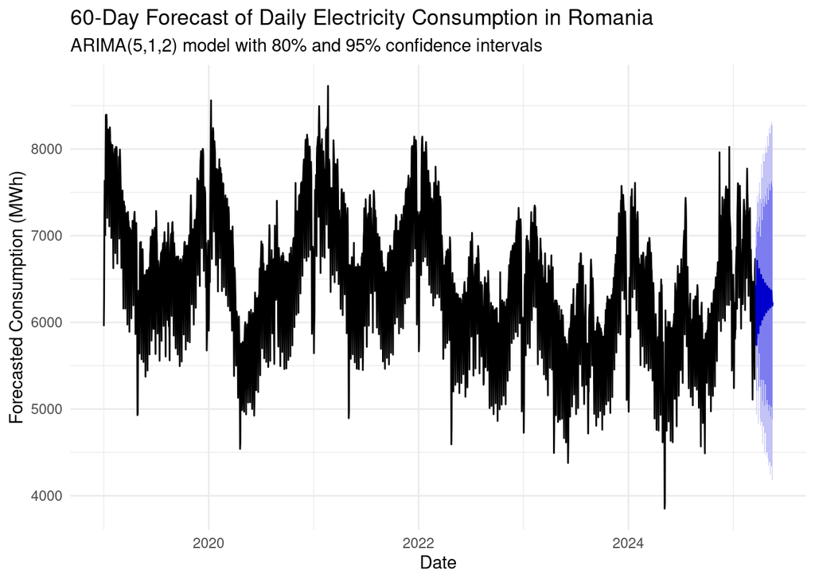

```r
#Forecast the next 60 days
forecast_60_arima <- forecast(fit_arima, h = 60)

#Plot the 60-day forecast
autoplot(forecast_60_arima) +
  labs(
    title = "60-Day Forecast of Daily Electricity Consumption in Romania",
    subtitle = "ARIMA(5,1,2) model with 80% and 95% confidence intervals",
    x = "Date",
    y = "Forecasted Consumption (MWh)"
  ) +
  theme_minimal()
```

#Interpretation of the Forecast

#The ARIMA(5,1,2) model projects Romania’s daily electricity consumption for the next 60 days, with forecasts centered around 6,000–6,500 MWh per day.

#The widening blue confidence bands represent growing uncertainty over time but the forecast trend remains realistic and consistent with historical behavior.